# Sentiment Analysis

Nick Browen

February 12, 2019

```r
library(tidyverse)
library(scales)
library(tidytext)
library(lubridate)
library(stringr)
library(purrr)
library(curl)
library(topicmodels)
library(lexicon)
library(wordcloud)
library(reshape2)
```

```r
reorder_within <- function(x, by, within, fun = mean, sep = "___", ...) {
  new_x <- paste(x, within, sep = sep)
  stats::reorder(new_x, by, FUN = fun)
}

scale_x_reordered <- function(..., sep = "___") {
  reg <- paste0(sep, ".+$")
  ggplot2::scale_x_discrete(labels = function(x) gsub(reg, "", x), ...)
}
```

# For Desktop

```r
tweets <- read.csv("tweets_te.csv")
tweets <- as_tibble(tweets)
tweets <- tweets %>% mutate(external_author_id = as.character(external_author_id),
                             author = as.character(author),
                             word = as.character(word),
                             token = as.character(token),
                             emoji = as.character(emoji),
                             region = as.character(region),
                             language = as.character(language),
                             account_type = as.character(account_type),
                             account_category = as.character(account_category),
                             publish_date = ymd_hms(publish_date),
                             harvested_date = ymd_hms(harvested_date),
                             emoji_bin = ifelse(is.na(emoji),"Word", "Emoji"))
```

### don’t run everytime

```
tweets_te_subset <- sample_n(tweets, dim(tweets)[1]*0.05)
write.csv(tweets_te_subset, "tweets_te_subset.csv")
```

```r
tweets_subset <- read.csv("tweets_te_subset.csv")
tweets_subset <-as_tibble(tweets_subset)
tweets_subset <- tweets_subset %>% mutate(external_author_id = as.character(external_author_id),
                             author = as.character(author),
                             word = as.character(word),
                             token = as.character(token),
                             emoji = as.character(emoji),
                             region = as.character(region),
                             language = as.character(language),
                             account_type = as.character(account_type),
                             account_category = as.character(account_category),
                             publish_date = ymd_hms(publish_date),
                             harvested_date = ymd_hms(harvested_date),
                             emoji_bin = ifelse(is.na(emoji),"Word", "Emoji"))
```

# For Laptop

```
tweets <- read.csv("tweets_te_subset.csv")
tweets <- as_tibble(tweets)
tweets <- tweets %>% mutate(external_author_id = as.character(external_author_id),
                             author = as.character(author),
                             word = as.character(word),
                             token = as.character(token),
                             emoji = as.character(emoji),
                             region = as.character(region),
                             language = as.character(language),
                             account_type = as.character(account_type),
                             account_category = as.character(account_category),
                             publish_date = ymd_hms(publish_date),
                             harvested_date = ymd_hms(harvested_date),
                             emoji_bin = ifelse(is.na(emoji),"Word", "Emoji"))
```

## Text Sentiment Analysis

### AFINN

```r
afinn <- get_sentiments("afinn")

tweets_sentiment <- tweets %>% inner_join(afinn) %>% mutate(afinn_score = score) %>% select(-score)
```

AFINN is a text sentiment lexicon that rates the sentiment of a word on a scale from -5 to 5.

```r
tweets_sentiment %>% select(afinn_score) %>% summary()
```

```
##   afinn_score
##  Min.   :-5.0000
##  1st Qu.:-2.0000
##  Median :-1.0000
##  Mean   :-0.6069
##  3rd Qu.: 2.0000
##  Max.   : 5.0000
```

```r
tweets_sentiment %>% group_by(account_category) %>% summarise(mean = mean(afinn_score), median = median(afinn_score), sd = sd(afinn_score)) %>% arrange(mean)
```

```
## # A tibble: 8 x 4
##   account_category    mean median    sd
##   <chr>              <dbl>  <dbl> <dbl>
## 1 NonEnglish       -1.36       -3  2.22
## 2 NewsFeed         -0.936      -2  1.99
## 3 RightTroll       -0.682      -1  2.17
## 4 Fearmonger       -0.605      -2  2.24
## 5 LeftTroll        -0.414      -1  2.32
## 6 HashtagGamer     -0.329      -1  2.40
## 7 Unknown           0.0680      1  2.46
## 8 Commercial        0.0901      1  2.41
```

NonEnglish is the most negative category, but after joining with the sentiment lexicon, “die” is the most common word at 372 which is a negative word in English, but in German means “the”. The next most common word is “war” which translates to “was” in German. I don’t think the sentiments are accurate for this category.

NewFeed is the next most negative category, which makes sense as news tends to be more negative. Top words in the sentiment lexicon include “killed”, “fire”, “arrested”, etc. Then RightTroll is the most negative category, followed by fearmonger, LeftTroll, and HashtagGamer. Commercial and Unknown are the only categories with positive average sentiments.

```r
aov(data = tweets_sentiment %>% filter(account_category %in% c("RightTroll", "LeftTroll", "NewsFeed", "HashtagGamer")), afinn_score ~ account_category) %>% summary()
```

```
##                      Df  Sum Sq Mean Sq F value Pr(>F)
## account_category      3   26031    8677    1798 <2e-16 ***
## Residuals        688517 3323327       5
## ---
## Signif. codes:  0 '***' 0.001 '**' 0.01 '*' 0.05 '.' 0.1 ' ' 1
```

```r
aov(data = tweets_sentiment %>% filter(account_category %in% c("RightTroll", "LeftTroll", "NewsFeed", "HashtagGamer")), afinn_score ~ account_category) %>% TukeyHSD()
```

```
##   Tukey multiple comparisons of means
##     95% family-wise confidence level
##
## Fit: aov(formula = afinn_score ~ account_category, data = tweets_sentiment %>% filter(account_category %in% c("RightTroll", "LeftTroll", "NewsFeed", "HashtagGamer")))
##
## $account_category
##                                diff        lwr         upr p adj
## LeftTroll-HashtagGamer  -0.08483546 -0.1102336 -0.05943732     0
## NewsFeed-HashtagGamer   -0.60751809 -0.6338900 -0.58114615     0
## RightTroll-HashtagGamer -0.35362391 -0.3765502 -0.33069757     0
## NewsFeed-LeftTroll      -0.52268262 -0.5444725 -0.50089276     0
## RightTroll-LeftTroll    -0.26878844 -0.2862509 -0.25132602     0
## RightTroll-NewsFeed      0.25389418  0.2350435  0.27274490     0
```

I’m not sure how useful/appropiate these tests are, but the overall F-test shows that at least one of the account category’s mean sentiment score is differnt from the other. The Tukey pairwise comparisons show us that each pair is statistically significantly different than each other.

```r
tweets_sentiment %>%
  mutate(retweet = case_when(retweet == 0 ~ "Original", retweet == 1 ~ "Retweet")) %>%
  group_by(retweet) %>%
  summarise(mean=mean(afinn_score)) %>%
  spread(key = retweet, value =mean) %>%
  mutate(diff = Original - Retweet)
```

```
## # A tibble: 1 x 3
##   Original Retweet   diff
##      <dbl>   <dbl>  <dbl>
## 1   -0.725  -0.444 -0.281
```

```r
tweets_sentiment %>%
  mutate(retweet = case_when(retweet == 0 ~ "Original", retweet == 1 ~ "Retweet")) %>%
  group_by(account_category, retweet) %>%
  summarise(mean=mean(afinn_score)) %>%
  spread(key = retweet, value =mean) %>%
  mutate(diff = Original - Retweet)
```

```
## # A tibble: 8 x 4
## # Groups:   account_category [8]
##   account_category Original Retweet    diff
##   <chr>               <dbl>   <dbl>   <dbl>
## 1 Commercial         0.0848   0.379 -0.294
## 2 Fearmonger        -0.629   -0.418 -0.211
## 3 HashtagGamer      -0.160   -0.403  0.243
## 4 LeftTroll         -0.577   -0.347 -0.230
## 5 NewsFeed          -0.936   -0.992  0.0563
## 6 NonEnglish        -2.20    -0.435 -1.77
## 7 RightTroll        -0.795   -0.532 -0.263
## 8 Unknown            0.475   -0.429  0.904
```

The trolls self-produced (original) tweets tend to be more negative than the tweets they are retweeting. The only categories this is not true for is HashtagGamer, NewsFeed, and Unknown.

# Word Cloud for LeftTroll Sentiment

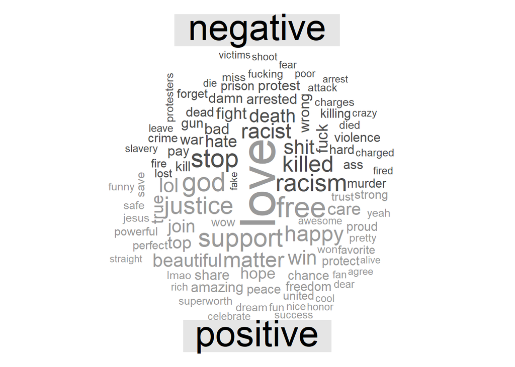

```r
tweets_sentiment %>% filter(account_category ==  "LeftTroll") %>% mutate(polarity = ifelse(afinn_score>0, "positive", "negative")) %>% group_by(polarity) %>% count(token, sort = T) %>% ungroup() %>% acast(token~polarity, value.var = "n", fill=0) %>% comparison.cloud(colors = c("gray30", "gray60"), max.words = 100)
```

# WordCloud for RightTroll Sentiment

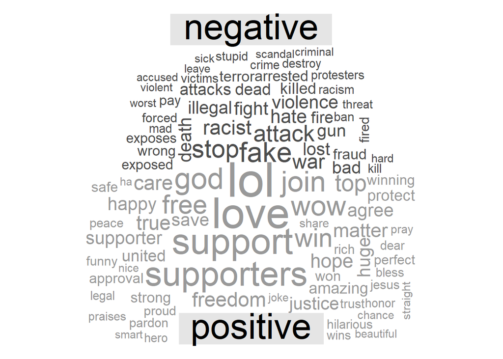

```r
tweets_sentiment %>% filter(account_category ==  "RightTroll") %>% mutate(polarity = ifelse(afinn_score>0, "positive", "negative")) %>% group_by(polarity) %>% count(token, sort = T) %>% ungroup() %>% acast(token~polarity, value.var = "n", fill=0) %>% comparison.cloud(colors = c("gray30", "gray60"), max.words = 100)
```

# sentiment over time

```r
tweets_sentiment %>% group_by(date = date(publish_date)) %>%
    summarise(mean_score = mean(afinn_score), n = n()) %>%
    summary()
```

```
##       date              mean_score            n
##  Min.   :2012-02-06   Min.   :-4.0000   Min.   :    1.0
##  1st Qu.:2015-08-25   1st Qu.:-0.8412   1st Qu.:   66.0
##  Median :2016-06-27   Median :-0.5888   Median :  414.0
##  Mean   :2016-05-24   Mean   :-0.4816   Mean   :  610.5
##  3rd Qu.:2017-04-30   3rd Qu.:-0.3217   3rd Qu.:  833.0
##  Max.   :2018-03-22   Max.   : 4.0000   Max.   :10254.0
```

```r
tweets_sentiment %>% group_by(date = date(publish_date)) %>%
    summarise(mean_score = mean(afinn_score), n = n()) %>%
    filter(n >10) %>%
    arrange(mean_score)
```

```
## # A tibble: 1,092 x 3
##    date       mean_score     n
##    <date>          <dbl> <int>
##  1 2016-07-21      -2.37   914
##  2 2017-11-03      -2.23    13
##  3 2017-11-29      -2.22  1517
##  4 2017-11-01      -1.75    16
##  5 2017-10-19      -1.66   788
##  6 2015-01-03      -1.64   109
##  7 2018-02-11      -1.6     15
##  8 2016-08-12      -1.59   752
##  9 2014-12-14      -1.56    18
## 10 2015-10-17      -1.52    44
## # ... with 1,082 more rows
```

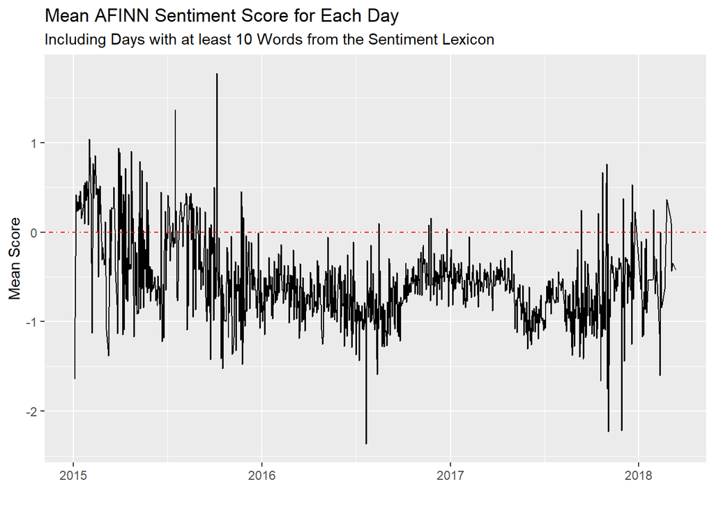

```r
tweets_sentiment %>% group_by(date = date(publish_date)) %>%
  filter(date >= as.Date("2015-01-01")) %>%
  summarise(mean_score = mean(afinn_score), n = n()) %>%
  filter(n > 10) %>%
  ungroup() %>%
  ggplot(aes(date, mean_score)) + geom_line() + geom_hline(yintercept =  0, colour = "red", linetype = 4) +
   labs(title = "Mean AFINN Sentiment Score for Each Day", subtitle = "Including Days with at least 10 Words from the Sentiment Lexicon",
        y = "Mean Score", x = "")
```

After filtering out days with less than 10 words, 2015 is still much more variable and positive than 2016-2018. There might be some slight seasonal trend as it seems to be slightly more positve, then go back down, then back up.

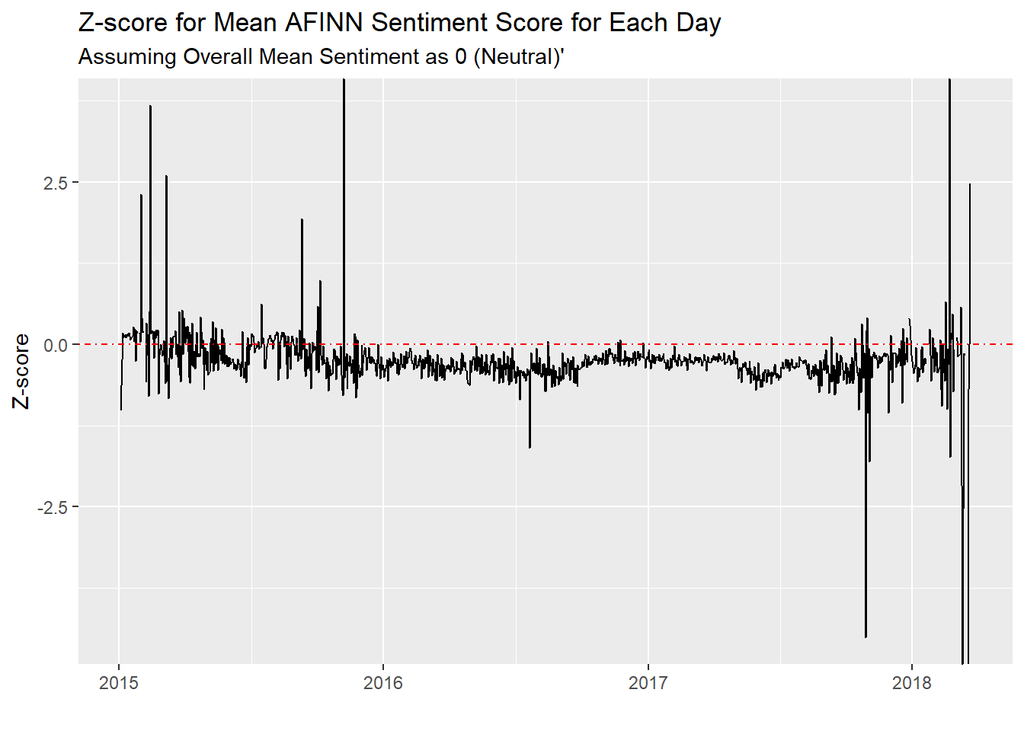

```r
tweets_sentiment %>% group_by(date = date(publish_date)) %>%
    filter(date >= as.Date("2015-01-01")) %>%
    summarise(mean_score = mean(afinn_score), n = n(), s = sd(afinn_score))  %>% mutate(z = (mean_score - 0)/s) %>% ggplot(aes(date, z)) + geom_line() + geom_hline(yintercept =  0, colour = "red", linetype = 4) +
  labs(title = "Z-score for Mean AFINN Sentiment Score for Each Day",subtitle = "Assuming Overall Mean Sentiment as 0 (Neutral)'", y = "Z-score", x = "")
```

The year 2015 is still much more variable than the other years. The years 2016-2018 are more negative, with semi-frequent large negative spikes.

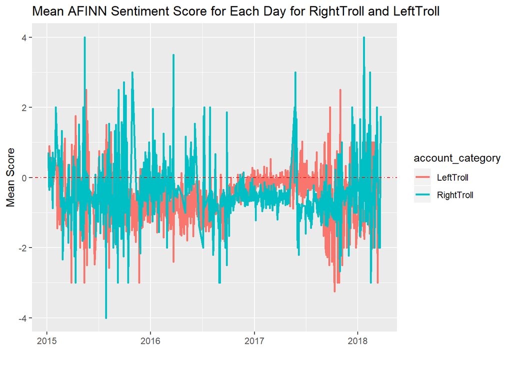

```r
tweets_sentiment  %>%
    filter(account_category %in% c("RightTroll", "LeftTroll")) %>% group_by(account_category, date = date(publish_date)) %>%
    filter(date >= as.Date("2015-01-01")) %>%
    summarise(mean_score = mean(afinn_score), n = n()) %>%
    ungroup() %>%
    ggplot(aes(date, mean_score, colour = account_category)) + geom_line(size =.9) + geom_hline(yintercept =  0, colour = "red", linetype = 4) +
    ggtitle("Mean AFINN Sentiment Score for Each Day for RightTroll and LeftTroll") + labs(y = "Mean Score", x = "")
```

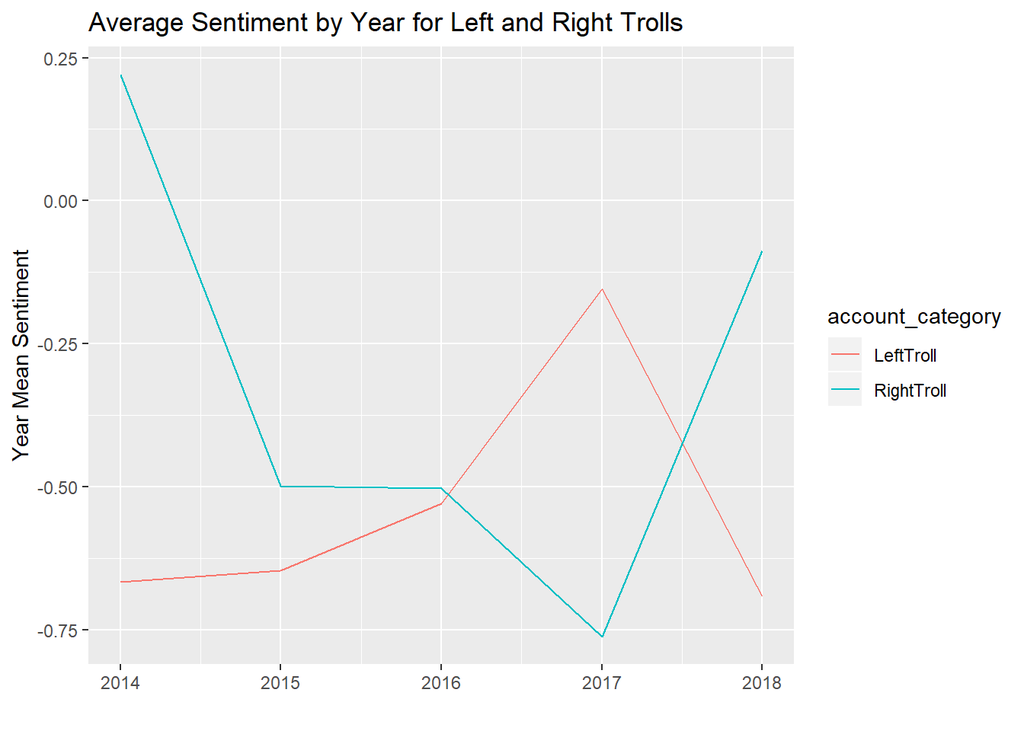

```r
tweets_sentiment %>% filter(account_category %in% c("LeftTroll", "RightTroll"), publish_date > as.Date("2014-01-01")) %>% group_by(account_category, year = year(publish_date)) %>% select(afinn_score) %>% summarise(mean = mean(afinn_score), sd = sd(afinn_score)) %>% ungroup() %>% ggplot(aes(year, mean, color=account_category)) + geom_line() + labs(title = "Average Sentiment by Year for Left and Right Trolls", y = "Year Mean Sentiment", x = "")
```

I’m not sure what to take from this graph. By year, RightTroll started more positive and peaked at its most negative in 2017 and then got more positive. LeftTrolls are almost the mirror opposite.

### NRC

The NRC lexicon groups words (non-exclusively) into 10 sentiment groups.

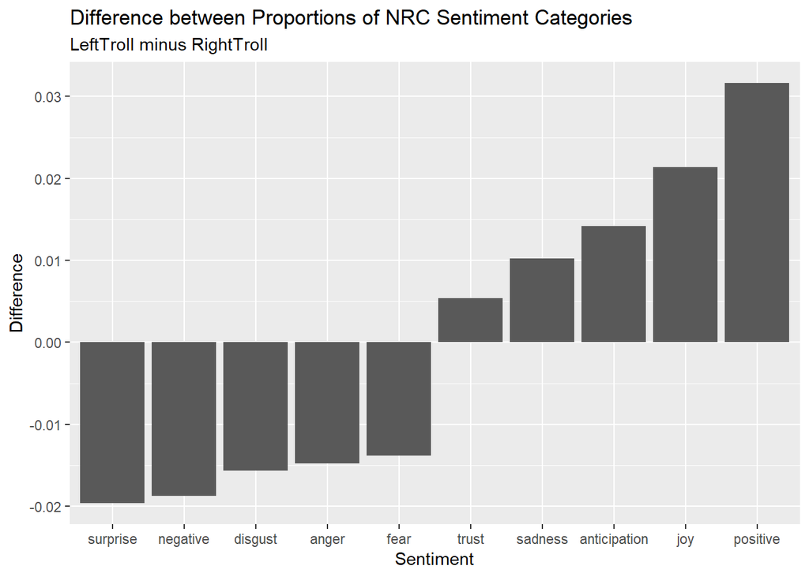

```r
tweets %>% inner_join(get_sentiments("nrc")) %>%
  filter(account_category %in% c("LeftTroll", "RightTroll")) %>%
  group_by(account_category) %>%
  count(sentiment) %>% arrange(sentiment) %>%
  mutate(sum = sum(n), proportion = n/sum) %>%
  select(account_category, proportion, sentiment)%>%
  spread(key = account_category, value = proportion) %>%
  mutate(diff = LeftTroll - RightTroll) %>%
  arrange(desc(abs(diff))) %>%
  ggplot(aes( reorder(sentiment, diff), diff)) + geom_col() + scale_x_reordered() +
      labs(y = "Difference", x = "Sentiment",
           title = "Difference between Proportions of NRC Sentiment Categories",
           subtitle = "LeftTroll minus RightTroll")
```

The biggest differences between categories are for positve, joy, surprise, and negative. The LeftTroll had a higher proportion of postive words (0.0316) and joyous words (0.0214). The RightTroll had a higher proportion of surprising words (-0.0197) and negative words (-0.0188). Interestingly, none of these categories have a larger difference than 0.0316, which is somewhat small and not very different.

## Emoji Sentiment Analysis

```r
tweets %>% filter(emoji_bin == "Emoji") %>% mutate(name = tolower(token))%>% inner_join(emojis_sentiment) %>% select(name, sentiment, positive, neutral, negative, account_category) %>% group_by(account_category) %>% summarise(mean = mean(sentiment)) %>% arrange(mean)
```

```
## # A tibble: 6 x 2
##   account_category  mean
##   <chr>            <dbl>
## 1 Commercial       0.356
## 2 Unknown          0.357
## 3 NonEnglish       0.370
## 4 LeftTroll        0.370
## 5 HashtagGamer     0.399
## 6 RightTroll       0.403
```

The RightTroll had the highest postive average sentiment score for their emojis. CommercialTroll had the lowest average postive score. However all categories’ average scores are within 0.0475958 points of each other.